# Peer-graded Assignment: Prediction Assignment Writeup

Aya Abdelmonem

10/9/2017

## Machine Learning course project

## Summary

### Using devices such as Jawbone Up, Nike FuelBand, and Fitbit it is now possible to collect a large amount of data about personal activity relatively inexpensively. These type of devices are part of the quantified self movement – a group of enthusiasts who take measurements about themselves regularly to improve their health, to find patterns in their behavior, or because they are tech geeks. One thing that people regularly do is quantify how much of a particular activity they do, but they rarely quantify how well they do it. In this project, your goal will be to use data from accelerometers on the belt, forearm, arm, and dumbell of 6 participants. They were asked to perform barbell lifts correctly and incorrectly in 5 different ways

## download training dataset and testing dataset and read these datasets into variables .

```r
library(downloader)
download.file("http://d396qusza40orc.cloudfront.net/predmachlearn/pml-training.csv","C:/Users/dell/Desktop/myDataScienceWork/machine learning/training.csv",mode = "wb")
download.file("https://d396qusza40orc.cloudfront.net/predmachlearn/pml-testing.csv","C:/Users/dell/Desktop/myDataScienceWork/machine learning/testing.csv",mode = "wb")
training_dataset <- read.csv("C:/Users/dell/Desktop/myDataScienceWork/machine learning/training.csv")
testing_dataset <- read.csv("C:/Users/dell/Desktop/myDataScienceWork/machine learning/testing.csv")
dim(training_dataset)
```

```
## [1] 19622   160
```

```r
head(training_dataset)
```

[output not shown]

[output cut: 265 more lines]

### As we can see that the first seven columns are useless in predicting out model , so we will get rid of these variables .

```r
training_dataset <- training_dataset[,-c(1:7)]
```

## Cleaning dataset from any missing value and remove variables near to zero variance .

```r
library(caret)
training_dataset <- training_dataset[,colSums(is.na(training_dataset))==0]
near_zero_var <- nearZeroVar(training_dataset)
training_dataset <- training_dataset[,-near_zero_var]
```

### We can take a look for data dimensions after doing some preprocessing analysis.

```r
dim(training_dataset)
```

```
## [1] 19622    53
```

## Partitioning train dataset into training set and test set .

### I will split it into 80% for training set and 20% for testing set .

```r
inTrain  <- createDataPartition(training_dataset$classe, p=0.8, list=FALSE)
train <- training_dataset[inTrain, ]
test  <- training_dataset[-inTrain, ]
```

## Loading required libraries

```r
library(ggplot2)
library(rpart)
require(randomForest)
```

## predictiion using Decision tree

```r
train_decision_tree <- rpart(classe ~ ., data = train, method = "class")
test_decision_tree <- predict(train_decision_tree, test, type = "class")
confusionMatrix(test_decision_tree, test$classe)
```

```
## Confusion Matrix and Statistics
##
##           Reference
## Prediction   A   B   C   D   E
##          A 990 160  21  63  26
##          B  33 426  71  30  74
##          C  26  54 504  91  81
##          D  54  50  44 424  58
##          E  13  69  44  35 482
##
## Overall Statistics
##
##                Accuracy : 0.7204
##                  95% CI : (0.706, 0.7344)
##     No Information Rate : 0.2845
##     P-Value [Acc > NIR] : < 2.2e-16
##
##                   Kappa : 0.6448
##  Mcnemar's Test P-Value : < 2.2e-16
##
## Statistics by Class:
##
##                      Class: A Class: B Class: C Class: D Class: E
## Sensitivity            0.8871   0.5613   0.7368   0.6594   0.6685
## Specificity            0.9038   0.9343   0.9222   0.9372   0.9497
## Pos Pred Value         0.7857   0.6719   0.6667   0.6730   0.7496
## Neg Pred Value         0.9527   0.8988   0.9432   0.9335   0.9271
## Prevalence             0.2845   0.1935   0.1744   0.1639   0.1838
## Detection Rate         0.2524   0.1086   0.1285   0.1081   0.1229
## Detection Prevalence   0.3212   0.1616   0.1927   0.1606   0.1639
## Balanced Accuracy      0.8955   0.7478   0.8295   0.7983   0.8091
```

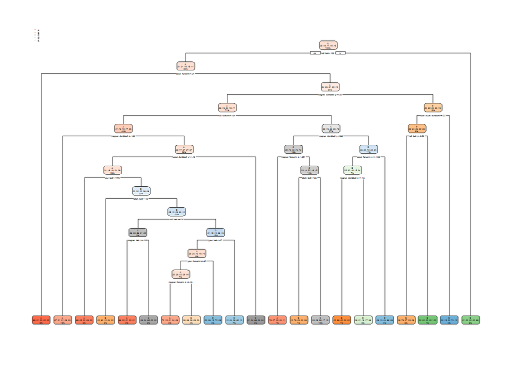

```r
rpart.plot::rpart.plot(train_decision_tree)
```

## Prediction using Random forest algorithm

```r
train_random_forest <- randomForest(classe ~. , data = train, type = "class")
test_random_forest  <- predict(train_random_forest, test, type = "class")
confusionMatrix(test_random_forest , test$classe)
```

```
## Confusion Matrix and Statistics
##
##           Reference
## Prediction    A    B    C    D    E
##          A 1116    3    0    0    0
##          B    0  756    3    0    0
##          C    0    0  681    4    0
##          D    0    0    0  638    1
##          E    0    0    0    1  720
##
## Overall Statistics
##
##                Accuracy : 0.9969
##                  95% CI : (0.9947, 0.9984)
##     No Information Rate : 0.2845
##     P-Value [Acc > NIR] : < 2.2e-16
##
##                   Kappa : 0.9961
##  Mcnemar's Test P-Value : NA
##
## Statistics by Class:
##
##                      Class: A Class: B Class: C Class: D Class: E
## Sensitivity            1.0000   0.9960   0.9956   0.9922   0.9986
## Specificity            0.9989   0.9991   0.9988   0.9997   0.9997
## Pos Pred Value         0.9973   0.9960   0.9942   0.9984   0.9986
## Neg Pred Value         1.0000   0.9991   0.9991   0.9985   0.9997
## Prevalence             0.2845   0.1935   0.1744   0.1639   0.1838
## Detection Rate         0.2845   0.1927   0.1736   0.1626   0.1835
## Detection Prevalence   0.2852   0.1935   0.1746   0.1629   0.1838
## Balanced Accuracy      0.9995   0.9975   0.9972   0.9960   0.9992
```

### As we see that the accuracy of random forest is 99% and this value is much better than the previous algorithm .

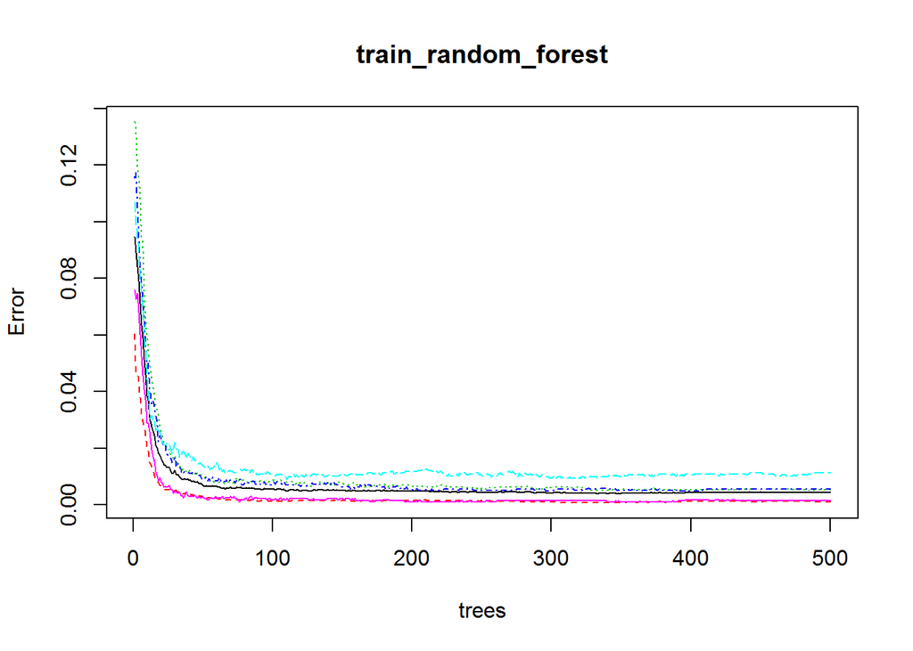

```r
plot(train_random_forest)
```

## Final model prediction

### We will use random forest algorithm to test the rest dataset

```r
final_model <- predict(train_random_forest, testing_dataset, type = "class")
final_model
```

```
##  1  2  3  4  5  6  7  8  9 10 11 12 13 14 15 16 17 18 19 20
##  B  A  B  A  A  E  D  B  A  A  B  C  B  A  E  E  A  B  B  B
## Levels: A B C D E
```